# Bowerman & Smith (2022) CogSci proceedings analysis, for github

Kenny Smith

01/06/2022

# Data loading etc

Read in anonymised data - clean-up has been done during the anonymisation process.

```r
data <- read.csv("cogsci_data_anonymised.csv")
```

## Number of pairs per condition

Quick look at number of remaining pairs per condition.

```r
plyr::ddply(data,~condition,plyr::summarise,Current_N=length(unique(pair_id)))
```

```
##             condition Current_N
## 1  fixed_associations        54
## 2 random_associations        53
```

# Plots and stats

## Plots and stats of success vs block

Score is recorded only on matcher trials so can discard the director trials for the score analyses.

```r
matcher_data <- subset(data,exp_trial_type=='matcher')
```

Score=1 on trials where the matcher succesfully selected the target, score=0 otherwise.

Plotting by-pair average score (i.e. proportion of score=1 trials) per block. I want a dotplot so we can individual pairs.

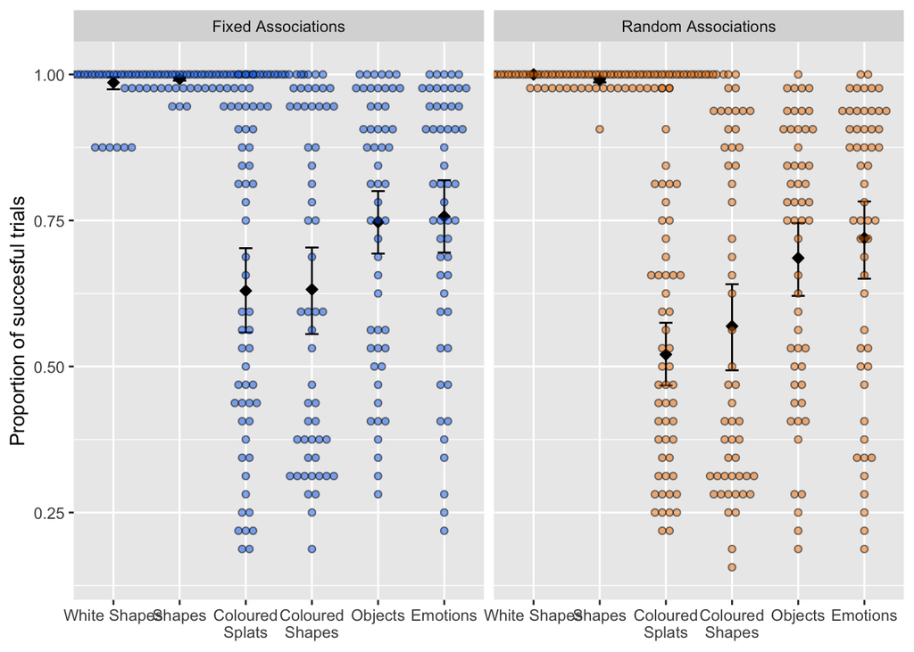

Same plot just showing block 2 onwards, since all the points clustered at 1 in block 1 makes it a bit hard to see what’s happening in block 2! This is Figure 2 (left) in the paper.

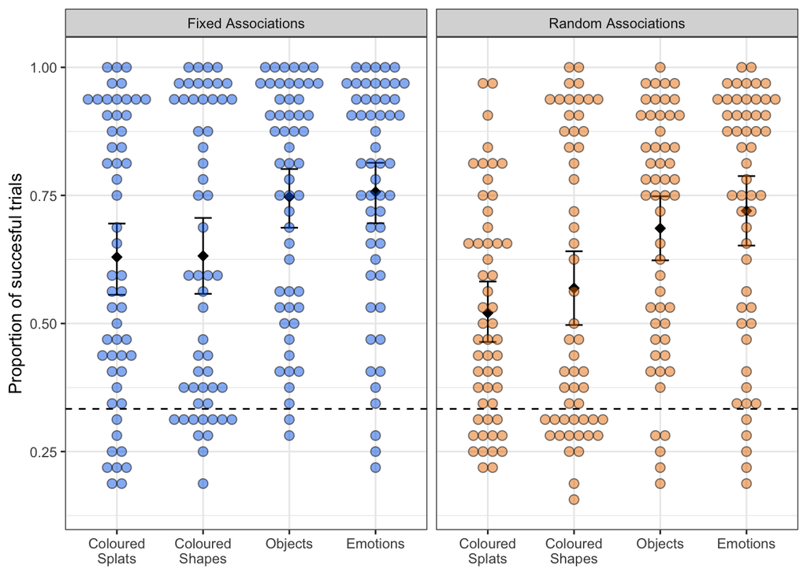

Given the very high performance, it should be sufficient to report that mean in blocks 0 (white shapes) and 1 (trivial shapes) is high.

Block 0.

```r
mean(subset(pair_means_per_block,block_n==0)$score)
```

```
## [1] 0.9929907
```

```r
stem(subset(pair_means_per_block,block_n==0)$score)
```

```
##
##   The decimal point is 2 digit(s) to the left of the |
##
##    87 | 555555
##    88 |
##    89 |
##    90 |
##    91 |
##    92 |
##    93 |
##    94 |
##    95 |
##    96 |
##    97 |
##    98 |
##    99 |
##   100 | 00000000000000000000000000000000000000000000000000000000000000000000+21
```

Block 1.

```r
mean(subset(pair_means_per_block,block_n==1)$score)
```

```
## [1] 0.9916764
```

```r
stem(subset(pair_means_per_block,block_n==1)$score)
```

```
##
##   The decimal point is 2 digit(s) to the left of the |
##
##    90 | 6
##    91 |
##    91 |
##    92 |
##    92 |
##    93 |
##    93 |
##    94 |
##    94 |
##    95 | 333
##    95 |
##    96 |
##    96 | 999999
##    97 |
##    97 |
##    98 | 444444444444444444444444444444
##    98 |
##    99 |
##    99 |
##   100 | 0000000000000000000000000000000000000000000000000000000000000000000
```

Key stat - are there effects of condition on score? We care about block 2 (splats) onwards. We predict particularly an effect at block 2 (the splats block), so want to get that straightforwardly from our analysis. We’d also like to know if the scores change over blocks, and whether this differ between conditions.

```r
matcher_data_block2on <- subset(matcher_data,block_n>=2)
matcher_data_block2on$block_n_factor <- as.factor(matcher_data_block2on$block_n)
matcher_data_block2on$condition_factor <- as.factor(matcher_data_block2on$condition)
contrasts(matcher_data_block2on$condition_factor) <- contr.sum(2)
```

Basic model with block dummy-coded - shows that the conditions differ at block 2, and that all subsequent blocks have higher accuracy than block 2; no condition * block interaction, so basically the random_association guys start lower and (according to this) stay lower, although you can see from the coefficients for later blocks that the difference is narrowing.

```r
#fails to converge with default settings, so using bobyqa and more iterations
score_model <- glmer(score~block_n_factor*condition_factor + (1 + block_n_factor | pair_id),data=matcher_data_block2on,family='binomial',control=glmerControl(optimizer="bobyqa",optCtrl=list(maxfun=100000)))

summary(score_model)
```

```
## Generalized linear mixed model fit by maximum likelihood (Laplace
##   Approximation) [glmerMod]
##  Family: binomial  ( logit )
## Formula:
## score ~ block_n_factor * condition_factor + (1 + block_n_factor |
##     pair_id)
##    Data: matcher_data_block2on
## Control:
## glmerControl(optimizer = "bobyqa", optCtrl = list(maxfun = 1e+05))
##
##      AIC      BIC   logLik deviance df.resid
##  14237.0  14372.5  -7100.5  14201.0    13678
##
## Scaled residuals:
##     Min      1Q  Median      3Q     Max
## -5.6373 -0.6877  0.2873  0.5666  1.8197
##
## Random effects:
##  Groups  Name            Variance Std.Dev. Corr
##  pair_id (Intercept)     1.4592   1.2080
##          block_n_factor3 0.4241   0.6513    0.38
##          block_n_factor4 0.8836   0.9400   -0.24  0.12
##          block_n_factor5 1.7270   1.3142   -0.37  0.00  0.66
## Number of obs: 13696, groups:  pair_id, 107
##
## Fixed effects:
##                                   Estimate Std. Error z value Pr(>|z|)
## (Intercept)                        0.46303    0.12422   3.727 0.000193 ***
## block_n_factor3                    0.26192    0.09040   2.897 0.003766 **
## block_n_factor4                    0.81724    0.11318   7.221 5.17e-13 ***
## block_n_factor5                    0.98031    0.14508   6.757 1.41e-11 ***
## condition_factor1                  0.32449    0.12396   2.618 0.008854 **
## block_n_factor3:condition_factor1 -0.08431    0.08775  -0.961 0.336649
## block_n_factor4:condition_factor1 -0.07882    0.11109  -0.710 0.477991
## block_n_factor5:condition_factor1 -0.18903    0.14339  -1.318 0.187405
## ---
## Signif. codes:  0 '***' 0.001 '**' 0.01 '*' 0.05 '.' 0.1 ' ' 1
##
## Correlation of Fixed Effects:
##             (Intr) blc__3 blc__4 blc__5 cndt_1 b__3:_ b__4:_
## blck_n_fct3  0.096
## blck_n_fct4 -0.308  0.240
## blck_n_fct5 -0.405  0.133  0.576
## cndtn_fctr1  0.010 -0.024 -0.018 -0.013
## blck_n_3:_1 -0.023  0.066  0.022  0.018  0.109
## blck_n_4:_1 -0.018  0.024  0.050  0.014 -0.308  0.242
## blck_n_5:_1 -0.013  0.019  0.015  0.018 -0.407  0.131  0.592
```

Same anaylsis with successive difference coding for block - this will show us block-to-block changes. NB the main effect of condition here is over all blocks (because of the way successive difference coding works), and the levels of the block factor are:

“2-1” is block 2 to block 3 “3-2” is block 3 to block 4 “4-3” is block 4 to block 5

This suggests that there is significant improvement from block 2 to block 3, and from 3 to 4, but no interaction with condition.

```r
matcher_data_block2on$block_n_factor_sdif <- matcher_data_block2on$block_n_factor
contrasts(matcher_data_block2on$block_n_factor_sdif) <- MASS::contr.sdif(4)
score_model_sdif <- glmer(score~block_n_factor_sdif*condition_factor + (1 + block_n_factor_sdif | pair_id),data=matcher_data_block2on,family='binomial',control=glmerControl(optimizer="bobyqa",optCtrl=list(maxfun=100000)))

summary(score_model_sdif)
```

```
## Generalized linear mixed model fit by maximum likelihood (Laplace
##   Approximation) [glmerMod]
##  Family: binomial  ( logit )
## Formula:
## score ~ block_n_factor_sdif * condition_factor + (1 + block_n_factor_sdif |
##     pair_id)
##    Data: matcher_data_block2on
## Control:
## glmerControl(optimizer = "bobyqa", optCtrl = list(maxfun = 1e+05))
##
##      AIC      BIC   logLik deviance df.resid
##  14237.0  14372.5  -7100.5  14201.0    13678
##
## Scaled residuals:
##     Min      1Q  Median      3Q     Max
## -5.6373 -0.6877  0.2873  0.5666  1.8197
##
## Random effects:
##  Groups  Name                   Variance Std.Dev. Corr
##  pair_id (Intercept)            1.4813   1.2171
##          block_n_factor_sdif2-1 0.4241   0.6512    0.54
##          block_n_factor_sdif3-2 1.1557   1.0750   -0.19 -0.50
##          block_n_factor_sdif4-3 0.9782   0.9890   -0.10 -0.12  0.01
## Number of obs: 13696, groups:  pair_id, 107
##
## Fixed effects:
##                                           Estimate Std. Error z value
## (Intercept)                               0.977886   0.120408   8.121
## block_n_factor_sdif2-1                    0.261898   0.090418   2.897
## block_n_factor_sdif3-2                    0.555333   0.126768   4.381
## block_n_factor_sdif4-3                    0.163074   0.122231   1.334
## condition_factor1                         0.236449   0.120206   1.967
## block_n_factor_sdif2-1:condition_factor1 -0.084317   0.087759  -0.961
## block_n_factor_sdif3-2:condition_factor1  0.005491   0.123791   0.044
## block_n_factor_sdif4-3:condition_factor1 -0.110205   0.118468  -0.930
##                                          Pr(>|z|)
## (Intercept)                              4.61e-16 ***
## block_n_factor_sdif2-1                    0.00377 **
## block_n_factor_sdif3-2                   1.18e-05 ***
## block_n_factor_sdif4-3                    0.18216
## condition_factor1                         0.04918 *
## block_n_factor_sdif2-1:condition_factor1  0.33666
## block_n_factor_sdif3-2:condition_factor1  0.96462
## block_n_factor_sdif4-3:condition_factor1  0.35224
## ---
## Signif. codes:  0 '***' 0.001 '**' 0.01 '*' 0.05 '.' 0.1 ' ' 1
##
## Correlation of Fixed Effects:
##             (Intr) bl___2-1 bl___3-2 bl___4-3 cndt_1 b___2-1: b___3-2:
## blck_n__2-1  0.383
## blck_n__3-2 -0.152 -0.499
## blck_n__4-3 -0.074 -0.064   -0.170
## cndtn_fctr1 -0.002 -0.001    0.003   -0.003
## bl___2-1:_1  0.000  0.066   -0.027    0.000    0.390
## bl___3-2:_1  0.002 -0.026    0.044   -0.026   -0.156 -0.491
## bl___4-3:_1 -0.003  0.000   -0.026    0.036   -0.078 -0.069   -0.149
```

## Plots and stats of success over block and trial per block

Timecourses are useful, but to do these sensibly we need to convert trial_n (which is overall trial number) to something more meaningful, specifically trial number *in a given block*. Since there is some variability in trial number depending on what participants did on the warm-up trials, need to work out per-pair the lowest trial number per block and then subtract that from the raw trial numbers.

```r
adjusted_trial_n_df <- NULL
for (p in unique(matcher_data$pair_id)) {
  this_p_data <- subset(matcher_data,pair_id==p)
  for (b in unique(this_p_data$block_n)) {
    this_b_data <- subset(this_p_data,block_n==b)
    first_trial_n <- min(this_b_data$trial_n)
    this_df <- data.frame("pair_id"=p,
               "block_n"=b,
               "trial_n"=this_b_data$trial_n,
               "trial_n_in_block"=this_b_data$trial_n-first_trial_n)
    adjusted_trial_n_df <- rbind(adjusted_trial_n_df,this_df)
  }
}

#merge to get the adjusted trial numbers.
matcher_data <- merge(matcher_data,adjusted_trial_n_df,by=c("pair_id","block_n","trial_n"))
```

Plot the timecourses - note I am plotting the mean of all pairs here (since the individual pairs either succeed or fail on any given trial, so those are not informative) plus bootstrepped CIs, and focussing only on blocks 2 (splats) onwards. This is Figure 2 (right) in the paper.

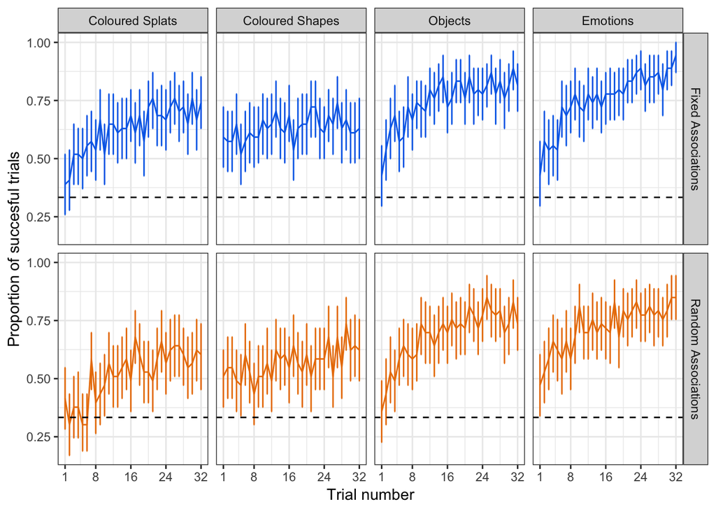

The question with the stats here is: is there a 3-way interaction between condition, block and trial number? Easiest way to find out is to compare models and do a likelihood ratio test, which suggests a marginal interaction.

```r
#need to re-run these since we have added the per-block trial numbers to matcher_data
matcher_data_block2on <- subset(matcher_data,block_n>=2)
matcher_data_block2on$block_n_factor <- as.factor(matcher_data_block2on$block_n)
matcher_data_block2on$condition_factor <- as.factor(matcher_data_block2on$condition)
contrasts(matcher_data_block2on$condition_factor) <- contr.sum(2)

#also need to scale and centre trial_n to ease convergence issues - setting so 0=-1, 31=1
matcher_data_block2on$trial_n_in_block_scaled_centred <- (matcher_data_block2on$trial_n_in_block-15.5)/15.5

score_model_trialn <- glmer(score~block_n_factor*condition_factor*trial_n_in_block_scaled_centred + (1 + block_n_factor * trial_n_in_block_scaled_centred | pair_id),data=matcher_data_block2on,family='binomial',control=glmerControl(optimizer="bobyqa",optCtrl=list(maxfun=100000)))
```

```
## boundary (singular) fit: see ?isSingular
```

```r
score_model_trialn_minus <- glmer(score~block_n_factor*condition_factor*trial_n_in_block_scaled_centred -block_n_factor:condition_factor:trial_n_in_block_scaled_centred + (1 + block_n_factor * trial_n_in_block_scaled_centred | pair_id),data=matcher_data_block2on,family='binomial',control=glmerControl(optimizer="bobyqa",optCtrl=list(maxfun=100000)))
```

```
## boundary (singular) fit: see ?isSingular
```

```r
anova(score_model_trialn,score_model_trialn_minus)
```

```
## Data: matcher_data_block2on
## Models:
## score_model_trialn_minus: score ~ block_n_factor * condition_factor * trial_n_in_block_scaled_centred -
## score_model_trialn_minus:     block_n_factor:condition_factor:trial_n_in_block_scaled_centred +
## score_model_trialn_minus:     (1 + block_n_factor * trial_n_in_block_scaled_centred | pair_id)
## score_model_trialn: score ~ block_n_factor * condition_factor * trial_n_in_block_scaled_centred +
## score_model_trialn:     (1 + block_n_factor * trial_n_in_block_scaled_centred | pair_id)
##                          Df   AIC   BIC  logLik deviance  Chisq Chi Df
## score_model_trialn_minus 49 13345 13714 -6623.7    13247
## score_model_trialn       52 13345 13736 -6620.4    13241 6.6595      3
##                          Pr(>Chisq)
## score_model_trialn_minus
## score_model_trialn          0.08358 .
## ---
## Signif. codes:  0 '***' 0.001 '**' 0.01 '*' 0.05 '.' 0.1 ' ' 1
```

Post-hocs: are there condition x trial number interactions at each block? These suggest marginal interactions at block 2 (which is clear in the graph) and block 5 (the fixed association people go up faster and reach a slightly higher level).

Block 2:

```r
score_model_trialn_block2 <- glmer(score~condition_factor*trial_n_in_block_scaled_centred + (1 + trial_n_in_block_scaled_centred | pair_id),data=subset(matcher_data_block2on,block_n==2),family='binomial',control=glmerControl(optimizer="bobyqa",optCtrl=list(maxfun=100000)))
summary(score_model_trialn_block2)
```

```
## Generalized linear mixed model fit by maximum likelihood (Laplace
##   Approximation) [glmerMod]
##  Family: binomial  ( logit )
## Formula: score ~ condition_factor * trial_n_in_block_scaled_centred +
##     (1 + trial_n_in_block_scaled_centred | pair_id)
##    Data: subset(matcher_data_block2on, block_n == 2)
## Control:
## glmerControl(optimizer = "bobyqa", optCtrl = list(maxfun = 1e+05))
##
##      AIC      BIC   logLik deviance df.resid
##   3794.5   3837.4  -1890.2   3780.5     3417
##
## Scaled residuals:
##     Min      1Q  Median      3Q     Max
## -7.6772 -0.7147  0.1359  0.6798  2.0327
##
## Random effects:
##  Groups  Name                            Variance Std.Dev. Corr
##  pair_id (Intercept)                     2.721    1.65
##          trial_n_in_block_scaled_centred 1.716    1.31     0.94
## Number of obs: 3424, groups:  pair_id, 107
##
## Fixed effects:
##                                                   Estimate Std. Error
## (Intercept)                                         0.7578     0.1720
## condition_factor1                                   0.4627     0.1694
## trial_n_in_block_scaled_centred                     1.2178     0.1595
## condition_factor1:trial_n_in_block_scaled_centred   0.2949     0.1536
##                                                   z value Pr(>|z|)
## (Intercept)                                         4.406 1.05e-05 ***
## condition_factor1                                   2.732   0.0063 **
## trial_n_in_block_scaled_centred                     7.636 2.25e-14 ***
## condition_factor1:trial_n_in_block_scaled_centred   1.920   0.0549 .
## ---
## Signif. codes:  0 '***' 0.001 '**' 0.01 '*' 0.05 '.' 0.1 ' ' 1
##
## Correlation of Fixed Effects:
##             (Intr) cndt_1 t_____
## cndtn_fctr1 0.045
## trl_n_n_b__ 0.830  0.066
## cnd_1:_____ 0.068  0.826  0.107
```

Block 3:

```r
score_model_trialn_block3 <- glmer(score~condition_factor*trial_n_in_block_scaled_centred + (1 + trial_n_in_block_scaled_centred | pair_id),data=subset(matcher_data_block2on,block_n==3),family='binomial',control=glmerControl(optimizer="bobyqa",optCtrl=list(maxfun=100000)))
summary(score_model_trialn_block3)
```

```
## Generalized linear mixed model fit by maximum likelihood (Laplace
##   Approximation) [glmerMod]
##  Family: binomial  ( logit )
## Formula: score ~ condition_factor * trial_n_in_block_scaled_centred +
##     (1 + trial_n_in_block_scaled_centred | pair_id)
##    Data: subset(matcher_data_block2on, block_n == 3)
## Control:
## glmerControl(optimizer = "bobyqa", optCtrl = list(maxfun = 1e+05))
##
##      AIC      BIC   logLik deviance df.resid
##   3649.6   3692.5  -1817.8   3635.6     3417
##
## Scaled residuals:
##     Min      1Q  Median      3Q     Max
## -6.5513 -0.7021  0.2027  0.5418  2.2950
##
## Random effects:
##  Groups  Name                            Variance Std.Dev. Corr
##  pair_id (Intercept)                     2.9519   1.7181
##          trial_n_in_block_scaled_centred 0.4589   0.6774   0.92
## Number of obs: 3424, groups:  pair_id, 107
##
## Fixed effects:
##                                                   Estimate Std. Error
## (Intercept)                                        0.81568    0.17578
## condition_factor1                                  0.20320    0.17405
## trial_n_in_block_scaled_centred                    0.57215    0.10928
## condition_factor1:trial_n_in_block_scaled_centred -0.04509    0.09954
##                                                   z value Pr(>|z|)
## (Intercept)                                         4.640 3.48e-06 ***
## condition_factor1                                   1.167    0.243
## trial_n_in_block_scaled_centred                     5.236 1.64e-07 ***
## condition_factor1:trial_n_in_block_scaled_centred  -0.453    0.651
## ---
## Signif. codes:  0 '***' 0.001 '**' 0.01 '*' 0.05 '.' 0.1 ' ' 1
##
## Correlation of Fixed Effects:
##             (Intr) cndt_1 t_____
## cndtn_fctr1 0.001
## trl_n_n_b__ 0.622  0.002
## cnd_1:_____ 0.007  0.636  0.034
```

Block 4:

```r
score_model_trialn_block4 <- glmer(score~condition_factor*trial_n_in_block_scaled_centred + (1 + trial_n_in_block_scaled_centred | pair_id),data=subset(matcher_data_block2on,block_n==4),family='binomial',control=glmerControl(optimizer="bobyqa",optCtrl=list(maxfun=100000)))
summary(score_model_trialn_block4)
```

```
## Generalized linear mixed model fit by maximum likelihood (Laplace
##   Approximation) [glmerMod]
##  Family: binomial  ( logit )
## Formula: score ~ condition_factor * trial_n_in_block_scaled_centred +
##     (1 + trial_n_in_block_scaled_centred | pair_id)
##    Data: subset(matcher_data_block2on, block_n == 4)
## Control:
## glmerControl(optimizer = "bobyqa", optCtrl = list(maxfun = 1e+05))
##
##      AIC      BIC   logLik deviance df.resid
##   3198.7   3241.7  -1592.4   3184.7     3417
##
## Scaled residuals:
##     Min      1Q  Median      3Q     Max
## -7.3848 -0.6520  0.1969  0.5171  2.1957
##
## Random effects:
##  Groups  Name                            Variance Std.Dev. Corr
##  pair_id (Intercept)                     3.477    1.865
##          trial_n_in_block_scaled_centred 2.035    1.427    0.87
## Number of obs: 3424, groups:  pair_id, 107
##
## Fixed effects:
##                                                   Estimate Std. Error
## (Intercept)                                         1.7874     0.2018
## condition_factor1                                   0.2944     0.1936
## trial_n_in_block_scaled_centred                     1.7294     0.1901
## condition_factor1:trial_n_in_block_scaled_centred   0.1006     0.1716
##                                                   z value Pr(>|z|)
## (Intercept)                                         8.857   <2e-16 ***
## condition_factor1                                   1.520    0.128
## trial_n_in_block_scaled_centred                     9.095   <2e-16 ***
## condition_factor1:trial_n_in_block_scaled_centred   0.587    0.557
## ---
## Signif. codes:  0 '***' 0.001 '**' 0.01 '*' 0.05 '.' 0.1 ' ' 1
##
## Correlation of Fixed Effects:
##             (Intr) cndt_1 t_____
## cndtn_fctr1 0.029
## trl_n_n_b__ 0.795  0.038
## cnd_1:_____ 0.040  0.782  0.065
```

Block 5:

```r
score_model_trialn_block5 <- glmer(score~condition_factor*trial_n_in_block_scaled_centred + (1 + trial_n_in_block_scaled_centred | pair_id),data=subset(matcher_data_block2on,block_n==5),family='binomial',control=glmerControl(optimizer="bobyqa",optCtrl=list(maxfun=100000)))
summary(score_model_trialn_block5)
```

```
## Generalized linear mixed model fit by maximum likelihood (Laplace
##   Approximation) [glmerMod]
##  Family: binomial  ( logit )
## Formula: score ~ condition_factor * trial_n_in_block_scaled_centred +
##     (1 + trial_n_in_block_scaled_centred | pair_id)
##    Data: subset(matcher_data_block2on, block_n == 5)
## Control:
## glmerControl(optimizer = "bobyqa", optCtrl = list(maxfun = 1e+05))
##
##      AIC      BIC   logLik deviance df.resid
##   2965.1   3008.0  -1475.5   2951.1     3417
##
## Scaled residuals:
##      Min       1Q   Median       3Q      Max
## -10.4504  -0.5683   0.1739   0.4806   2.2517
##
## Random effects:
##  Groups  Name                            Variance Std.Dev. Corr
##  pair_id (Intercept)                     4.12     2.030
##          trial_n_in_block_scaled_centred 1.84     1.357    0.95
## Number of obs: 3424, groups:  pair_id, 107
##
## Fixed effects:
##                                                   Estimate Std. Error
## (Intercept)                                         2.0756     0.2226
## condition_factor1                                   0.2624     0.2117
## trial_n_in_block_scaled_centred                     2.0108     0.1959
## condition_factor1:trial_n_in_block_scaled_centred   0.3323     0.1700
##                                                   z value Pr(>|z|)
## (Intercept)                                         9.324   <2e-16 ***
## condition_factor1                                   1.240   0.2151
## trial_n_in_block_scaled_centred                    10.266   <2e-16 ***
## condition_factor1:trial_n_in_block_scaled_centred   1.955   0.0506 .
## ---
## Signif. codes:  0 '***' 0.001 '**' 0.01 '*' 0.05 '.' 0.1 ' ' 1
##
## Correlation of Fixed Effects:
##             (Intr) cndt_1 t_____
## cndtn_fctr1 0.036
## trl_n_n_b__ 0.837  0.056
## cnd_1:_____ 0.058  0.833  0.091
```

## Block-to-block distances in association matrices

The basic idea is that participants (at least in the fixed condition) will use the associations between colour and shape established in block 1 as the basis for the colour-shape mapping in block 2 (coliured splats, where they must discriminate between 3 differently-coloured splats), and then use whatever associations they develop in block 2 in block 3 (coloured shapes, where they must discriminate between 3 instances of the same shape differing only in colour), and so on into block 4 (objects) and block 5 (emotions).

NB ha ha, these examples aren’t displaying in the generated text in the table layout I intended, will fix later!

and for the random associations the matrix should be more uniformly filled, since any shape can be any colour.

In block 2, where they lable splats, we can perform the same operation and get out a similar matrix - e.g. if they were using the same set of colour-shape associations at block 2, we would get something like:

target_colour cross hexagon square star grey 0 0 0 4 pink 0 4 0 0 red 0 0 4 0 yellow 4 0 0 0

and if they were doing something completely different we’d get different associations, e.g.

target_colour cross hexagon square star grey 4 0 0 4 pink 0 0 4 0 red 0 0 0 4 yellow 0 4 0 0

If we normalise both matrices (to control for the fact that block 1 is longer than subsequent blocks) and then take the absolute difference between these two matrices, then we get a difference matrix which will be all 0s if the 2 matrices are the same, and will contain non-0 elements of the two matrices are not identical - if we sum the numbers in that difference matrix that then gives us a measure of distance between their mappings. This isn’t quite what we want, because two random mappings will tend to be more similar to each other than two non-random mappings, so we have to control for that - we can do that using a permutation test, where we say “what would the distribution of distance scores look like if we shuffled one of these matrices?”, then convert the *actual* distance score into a z-score based on this distribution. Distance z-scores of around 0 mean that two matrices are no more similar than you would expect by chance, and negative distance z scores mean they are more similar (i.e. lower distance) than you would expect by chance. Then we can just plot those scores, comparing block 1 to block 2, block 2 to block 3, etc.

Code for this matrix distance z-scoring.

```r
#number of trials to use for z-score calculation
mc_trials = 1000

#calculates z score on simple distance between two matrices. NB this is currently NA if the two matrices are of different size, which is not ideal - really I should force them to have the same dimensions by entering all-0 columns, but there are very few cases where a participant does not use one of the available labels.
normalised_distance <- function(a,b) {
  #normalise by rows
  norm_a <- sweep(a, 1, rowSums(a), FUN = "/")
  norm_b <- sweep(b, 1, rowSums(b), FUN = "/")
  veridical_dist <- sum(abs(norm_a-norm_b))
  veridical_dist}

matrix_distance_z <- function(a,b) {
  if (all(dim(a)==dim(b))) {
    veridical_distance <- normalised_distance(a,b)
    msample <- replicate(mc_trials,normalised_distance(a,b[,sample(ncol(b))]))
    c=0
    for (i in 1:mc_trials) {
      if(msample[i]>=veridical_distance) c=c+1
    }
    return(list(mean=mean(msample),sd=sd(msample),veridical=veridical_distance,p=c/mc_trials,z=(veridical_distance-mean(msample))/sd(msample)))
  }
  else {
    return(list(mean=NA,sd=NA,veridical=NA,p=NA,z=NA))
  }
  }
```

Data prep for doing the analysis.

```r
get_target_colour <- function(target_object) {
  strsplit(as.character(target_object),"_")[[1]][2]
}

get_target_shape <- function(target_object) {
  strsplit(as.character(target_object),"_")[[1]][1]
}

#shapes and colours are always separated by an underscore, so we can check for that
get_key_feature <- function(target_object) {
  if (grepl('_',as.character(target_object))) {
    get_target_colour(target_object)
  }
  else {as.character(target_object)}
}

director_data <- subset(data,exp_trial_type=='director' & block_n>0)
#need to extract colour, object or shape from the object column.
director_data$key_feature <- mapply(function(target) get_key_feature(target),
                                                   director_data$object)
#need to set up the levels of the key feature so that when we tabulate within a block we always get
#the desired order of levels across blocks
director_data$key_feature <- factor(director_data$key_feature,levels=c("grey","pink","red","yellow",
                                                      "city","pig","volcano","banana",
                                                      "sad","inlove","angry","happy"))
```

Code for tabulating and calculating distances per pair.

```r
tabulate_pair <- function(all_data,id,print_output=FALSE) {
  this_pair_data <- subset(all_data,pair_id==id)
  this_pair_matrices <- list()
  if (print_output) {print(paste(id,unique(this_pair_data$condition)))}

  for (b in unique(all_data$block_n)) {
    this_block_associations <- subset(this_pair_data,block_n==b)
    this_block_associations_xtab <- xtabs(data=this_block_associations,~key_feature+label,drop.unused.levels=TRUE)
  if (print_output) {
    print(paste("block",b,"colour-shape associations"))
    print(this_block_associations_xtab)}
  this_block_associations_matrix <- matrix(this_block_associations_xtab,
                                            dim(this_block_associations_xtab))
  this_pair_matrices[[b]] <- this_block_associations_matrix
  }
  #now we have all the block matrices we can compare
  block_1_2_dist <- matrix_distance_z(this_pair_matrices[[1]],this_pair_matrices[[2]])$z
  block_2_3_dist <- matrix_distance_z(this_pair_matrices[[2]],this_pair_matrices[[3]])$z
  block_3_4_dist <- matrix_distance_z(this_pair_matrices[[3]],this_pair_matrices[[4]])$z
  block_4_5_dist <- matrix_distance_z(this_pair_matrices[[4]],this_pair_matrices[[5]])$z



  this_dist_data <- data.frame("pair_id"=id,
                                 "condition"=unique(this_pair_data$condition),
                                 "blocks"=c("1-2","2-3","3-4","4-5"),
                                 "distance"=c(block_1_2_dist,block_2_3_dist,block_3_4_dist,block_4_5_dist)
  )
  this_dist_data

}
```

Finally, calculate the distances and compile into a dataframe called block_to_block_distances.

```r
block_to_block_distances <- do.call(rbind, lapply(unique(director_data$pair_id), function(p) tabulate_pair(director_data,p)))
```

And plot. NB I forgot to record the seed I used for the analysis in the cogsci paper and since the z-scoring is stochastic the values might differ by a small amount from those in the paper! But nothwithstanding that caveatm, this is Figure 3.

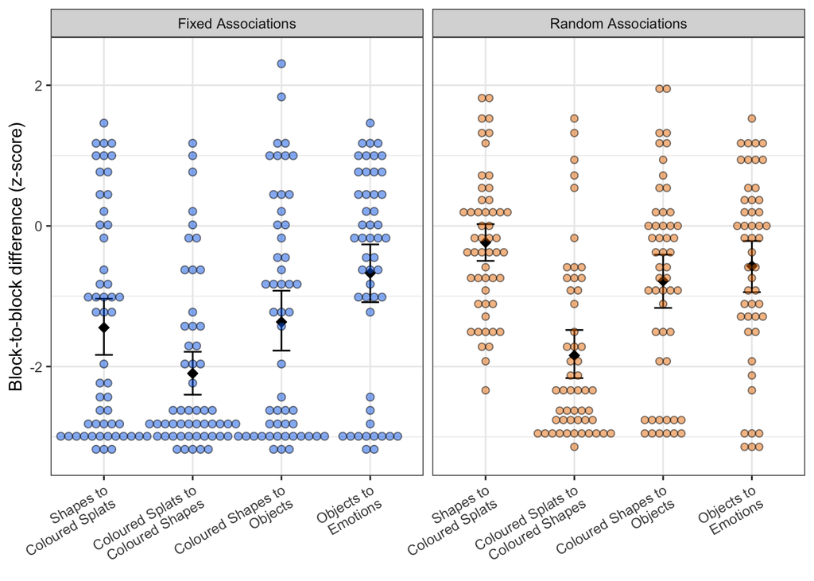

Stats - first, dummy-coded model to show no difference between conditions at block 3.

```r
block_to_block_distances_3onwards <- subset(block_to_block_distances, blocks != "1-2")
block_to_block_distances_3onwards$blocks <- droplevels(block_to_block_distances_3onwards$blocks)


block_to_block_distances_model_dummy <-  lmerTest::lmer(distance~blocks*condition + (1 | pair_id),data=block_to_block_distances_3onwards,control=lmerControl(optimizer="bobyqa",optCtrl=list(maxfun=100000)))
summary(block_to_block_distances_model_dummy)
```

```
## Linear mixed model fit by REML. t-tests use Satterthwaite's method [
## lmerModLmerTest]
## Formula: distance ~ blocks * condition + (1 | pair_id)
##    Data: block_to_block_distances_3onwards
## Control: lmerControl(optimizer = "bobyqa", optCtrl = list(maxfun = 1e+05))
##
## REML criterion at convergence: 1042.7
##
## Scaled residuals:
##      Min       1Q   Median       3Q      Max
## -1.97623 -0.67070  0.01524  0.52020  2.31790
##
## Random effects:
##  Groups   Name        Variance Std.Dev.
##  pair_id  (Intercept) 0.7754   0.8806
##  Residual             1.1866   1.0893
## Number of obs: 308, groups:  pair_id, 107
##
## Fixed effects:
##                                        Estimate Std. Error       df
## (Intercept)                             -2.0843     0.1921 235.1764
## blocks3-4                                0.7247     0.2138 203.0106
## blocks4-5                                1.4523     0.2159 202.3029
## conditionrandom_associations             0.2526     0.2729 235.4588
## blocks3-4:conditionrandom_associations   0.3290     0.3028 201.9825
## blocks4-5:conditionrandom_associations  -0.2074     0.3072 202.7579
##                                        t value Pr(>|t|)
## (Intercept)                            -10.848  < 2e-16 ***
## blocks3-4                                3.389 0.000843 ***
## blocks4-5                                6.728 1.73e-10 ***
## conditionrandom_associations             0.926 0.355601
## blocks3-4:conditionrandom_associations   1.087 0.278459
## blocks4-5:conditionrandom_associations  -0.675 0.500295
## ---
## Signif. codes:  0 '***' 0.001 '**' 0.01 '*' 0.05 '.' 0.1 ' ' 1
##
## Correlation of Fixed Effects:
##             (Intr) blc3-4 blc4-5 cndtn_ b3-4:_
## blocks3-4   -0.549
## blocks4-5   -0.540  0.492
## cndtnrndm_s -0.704  0.387  0.380
## blcks3-4:c_  0.388 -0.706 -0.348 -0.551
## blcks4-5:c_  0.379 -0.346 -0.703 -0.541  0.493
```

Then, successive-differences model to show change over time.

```r
block_to_block_distances_3onwards$blocks_sdif <- block_to_block_distances_3onwards$blocks
contrasts(block_to_block_distances_3onwards$blocks_sdif) <- MASS::contr.sdif(3)
contrasts(block_to_block_distances_3onwards$condition) <- contr.sum(2)

block_to_block_distances_model_sdif <-  lmerTest::lmer(distance~blocks_sdif*condition + (1 | pair_id),data=block_to_block_distances_3onwards,control=lmerControl(optimizer="bobyqa",optCtrl=list(maxfun=100000)))
summary(block_to_block_distances_model_sdif)
```

```
## Linear mixed model fit by REML. t-tests use Satterthwaite's method [
## lmerModLmerTest]
## Formula: distance ~ blocks_sdif * condition + (1 | pair_id)
##    Data: block_to_block_distances_3onwards
## Control: lmerControl(optimizer = "bobyqa", optCtrl = list(maxfun = 1e+05))
##
## REML criterion at convergence: 1046.9
##
## Scaled residuals:
##      Min       1Q   Median       3Q      Max
## -1.97623 -0.67070  0.01524  0.52020  2.31790
##
## Random effects:
##  Groups   Name        Variance Std.Dev.
##  pair_id  (Intercept) 0.7754   0.8806
##  Residual             1.1866   1.0893
## Number of obs: 308, groups:  pair_id, 107
##
## Fixed effects:
##                           Estimate Std. Error       df t value Pr(>|t|)
## (Intercept)                -1.2120     0.1058 105.3598 -11.456  < 2e-16
## blocks_sdif2-1              0.8892     0.1514 201.9825   5.874 1.73e-08
## blocks_sdif3-2              0.4594     0.1535 200.9853   2.992  0.00312
## condition1                 -0.1466     0.1058 105.3598  -1.385  0.16886
## blocks_sdif2-1:condition1  -0.1645     0.1514 201.9825  -1.087  0.27846
## blocks_sdif3-2:condition1   0.2682     0.1535 200.9853   1.747  0.08218
##
## (Intercept)               ***
## blocks_sdif2-1            ***
## blocks_sdif3-2            **
## condition1
## blocks_sdif2-1:condition1
## blocks_sdif3-2:condition1 .
## ---
## Signif. codes:  0 '***' 0.001 '**' 0.01 '*' 0.05 '.' 0.1 ' ' 1
##
## Correlation of Fixed Effects:
##             (Intr) bl_2-1 bl_3-2 cndtn1 b_2-1:
## blcks_sd2-1  0.005
## blcks_sd3-2  0.016 -0.493
## condition1  -0.006  0.003 -0.002
## blcks_2-1:1  0.003 -0.002 -0.002  0.005
## blcks_3-2:1 -0.002 -0.002 -0.006  0.016 -0.493
```

## Non-arbitrariness of colour-shape correspondences in the arbitrary condition

One final question here is: how are the people in the random associations condition doing it in block 2 (splats, where they suddenly have to start talking about colour) - are they coming up with something arbitrary, or are there certain asociations between colour and shape we were not anticipating?

Probaby the simplest way to do this is just to generate a big association table and look for non-uniformity.

This actually reveals some obvious ones: star=yellow, cross=red.

```r
random_block2_associations_data <- subset(director_data,block_n==2 & condition=='random_associations')
random_block2_associations_xtab <- xtabs(data=random_block2_associations_data,~key_feature+label,drop.unused.levels=TRUE)
random_block2_associations_xtab
```

```
##            label
## key_feature circle cross diamond hexagon pentagon square star
##      grey       97    42      36      69       59     83   38
##      pink       60    68      75      62       62     58   39
##      red        69   106      34      40       40     84   51
##      yellow     67    69      36      30       53     37  132
```

```r
chisq.test(random_block2_associations_xtab)
```

```
##
##  Pearson's Chi-squared test
##
## data:  random_block2_associations_xtab
## X-squared = 208.37, df = 18, p-value < 2.2e-16
```

Do we still get an association if we remove star and cross? Yes we do, e.g. grey and red go with circle and square, pink maybe goes with diamond, etc.

```r
random_block2_associations_nostarcross_xtab <- xtabs(data=subset(random_block2_associations_data, !(label %in% c('star','cross'))),~key_feature+label,drop.unused.levels=TRUE)
random_block2_associations_nostarcross_xtab
```

```
##            label
## key_feature circle diamond hexagon pentagon square
##      grey       97      36      69       59     83
##      pink       60      75      62       62     58
##      red        69      34      40       40     84
##      yellow     67      36      30       53     37
```

```r
chisq.test(random_block2_associations_nostarcross_xtab)
```

```
##
##  Pearson's Chi-squared test
##
## data:  random_block2_associations_nostarcross_xtab
## X-squared = 54.88, df = 12, p-value = 1.902e-07
```

Are there any colours which *don’t* have a preference? Maybe only pink, which is only marginally different from uniform.

```r
for (colour in c("grey","pink","red","yellow")) {
  random_block2_associations_for_this <- xtabs(data=subset(random_block2_associations_data, key_feature==colour),~key_feature+label,drop.unused.levels=TRUE)
  print(random_block2_associations_for_this)
  print(chisq.test(random_block2_associations_for_this)$p.value)
}
```

```
##            label
## key_feature circle cross diamond hexagon pentagon square star
##        grey     97    42      36      69       59     83   38
## [1] 3.67366e-10
##            label
## key_feature circle cross diamond hexagon pentagon square star
##        pink     60    68      75      62       62     58   39
## [1] 0.05739756
##            label
## key_feature circle cross diamond hexagon pentagon square star
##         red     69   106      34      40       40     84   51
## [1] 2.062683e-13
##            label
## key_feature circle cross diamond hexagon pentagon square star
##      yellow     67    69      36      30       53     37  132
## [1] 7.501761e-24
```

Worth doing this in block 3 as well - block 2 will capture the early try-anything stages of convention formation, block 3 (talking about shapes) should show us the settled systems (which could show these preferences more clearly, or get rid of the initial panicked iconic efforts). Picture looks the same - even pink is significant at this point, although possibly due to avoiding star, circle and square.

```r
random_block3_associations_data <- subset(director_data,block_n==3 & condition=='random_associations')
random_block3_associations_xtab <- xtabs(data=random_block3_associations_data,~key_feature+label,drop.unused.levels=TRUE)
random_block3_associations_xtab
```

```
##            label
## key_feature circle cross diamond hexagon pentagon square star
##      grey       90    26      51      73       64     94   26
##      pink       55    61      89      73       74     51   21
##      red        63   105      53      38       47     83   35
##      yellow     72    70      34      22       49     47  130
```

```r
chisq.test(random_block3_associations_xtab)
```

```
##
##  Pearson's Chi-squared test
##
## data:  random_block3_associations_xtab
## X-squared = 307.79, df = 18, p-value < 2.2e-16
```

```r
for (colour in c("grey","pink","red","yellow")) {
  random_block3_associations_for_this <- xtabs(data=subset(random_block3_associations_data, key_feature==colour),~key_feature+label,drop.unused.levels=TRUE)
  print(random_block3_associations_for_this)
  print(chisq.test(random_block3_associations_for_this)$p.value)
}
```

```
##            label
## key_feature circle cross diamond hexagon pentagon square star
##        grey     90    26      51      73       64     94   26
## [1] 1.914132e-14
##            label
## key_feature circle cross diamond hexagon pentagon square star
##        pink     55    61      89      73       74     51   21
## [1] 2.098728e-08
##            label
## key_feature circle cross diamond hexagon pentagon square star
##         red     63   105      53      38       47     83   35
## [1] 6.330553e-12
##            label
## key_feature circle cross diamond hexagon pentagon square star
##      yellow     72    70      34      22       49     47  130
## [1] 1.696942e-24
```

I also wonder if we can see anything in block 5 (in the fixed condition in particular) - is there some shape-emotion correspondence messing with the colour-shape stuff? Nothing that massively jumps out, although you can see the signature of the same shape-colour correspondences we see in the random condition.

```r
fixed_block5_associations_data <- subset(director_data,block_n==5 & condition=="fixed_associations")
fixed_block5_associations_data <- xtabs(data=fixed_block5_associations_data,~key_feature+label,drop.unused.levels=TRUE)
fixed_block5_associations_data
```

```
##            label
## key_feature circle cross diamond hexagon pentagon square star
##      sad        62    73      40      98       60     57   42
##      inlove     59    71      67      41       68     61   65
##      angry      33   104      59      63       54     64   55
##      happy      78    47      51      44       32     38  142
```

```r
chisq.test(fixed_block5_associations_data)
```

```
##
##  Pearson's Chi-squared test
##
## data:  fixed_block5_associations_data
## X-squared = 181.79, df = 18, p-value < 2.2e-16
```

For reference, here’s what their block 2 associations look like - you can see that they are influenced by the same colour-shape associations as the guys in random, so they are using the statistical associations we give them (that’s what the z-scores show) but *also* the iconic stuff like red=cross, yellow=star.

```r
fixed_block2_associations_data <- subset(director_data,block_n==2 & condition=="fixed_associations")
fixed_block2_associations_data <- xtabs(data=fixed_block2_associations_data,~key_feature+label,drop.unused.levels=TRUE)
fixed_block2_associations_data
```

```
##            label
## key_feature circle cross diamond hexagon pentagon square star
##      grey       54    55      20      65       57     80  101
##      pink       74    48      69      63       57     25   96
##      red        28    87      36      63       48     76   94
##      yellow     61    59      51      40       49     48  124
```

```r
chisq.test(fixed_block2_associations_data)
```

```
##
##  Pearson's Chi-squared test
##
## data:  fixed_block2_associations_data
## X-squared = 113.78, df = 18, p-value = 6.209e-16
```